# Categorical class 6

# Packages

```r
library(haven)      # read in SPSS data
library(ggplot2)    # plots
theme_set(theme_classic(base_size = 16)) # Set ggplot theme and increase font
library(dplyr)      # data manipulation
library(MASS)       # negative binomial regression
library(pscl)       # predprob() function for predicted counts
                    # zeroinfl() function for zero-inflated count models
                    # hurdle() for hurdle count models
                    # vuong() for non-nested model comparisons
library(performance)    # R^2 values
library(lmtest)     # LR tests
library(kableExtra) # prettier tables in HTML
```

# Data

- Simulated data from Coxe, S., West, S. G., & Aiken, L. S. (2009). The analysis of count data: A gentle introduction to Poisson regression and its alternatives. *Journal of Personality Assessment, 91(2)*, 121-136.
  - `case`: Subject ID
  - `sensation`: Sensation seeking (1 to 7)
  - `gender`: 0 = female, 1 = male
  - `y`: Number of alcoholic beverages consumed on Saturday night

```r
jpa <- read_sav("jpapoisson.sav")
head(jpa, n = 10)
```

```
# A tibble: 10 × 4
    case sensation gender     y
   <dbl>     <dbl>  <dbl> <dbl>
 1     1      6.06      1     4
 2     2      5.31      1     4
 3     3      3.94      1     1
 4     4      4.30      1     6
 5     5      5.58      1     0
 6     6      4.89      1     8
 7     7      4.51      0     6
 8     8      6.16      0     1
 9     9      4.19      1     7
10    10      5.64      1     8
```

## Outcome

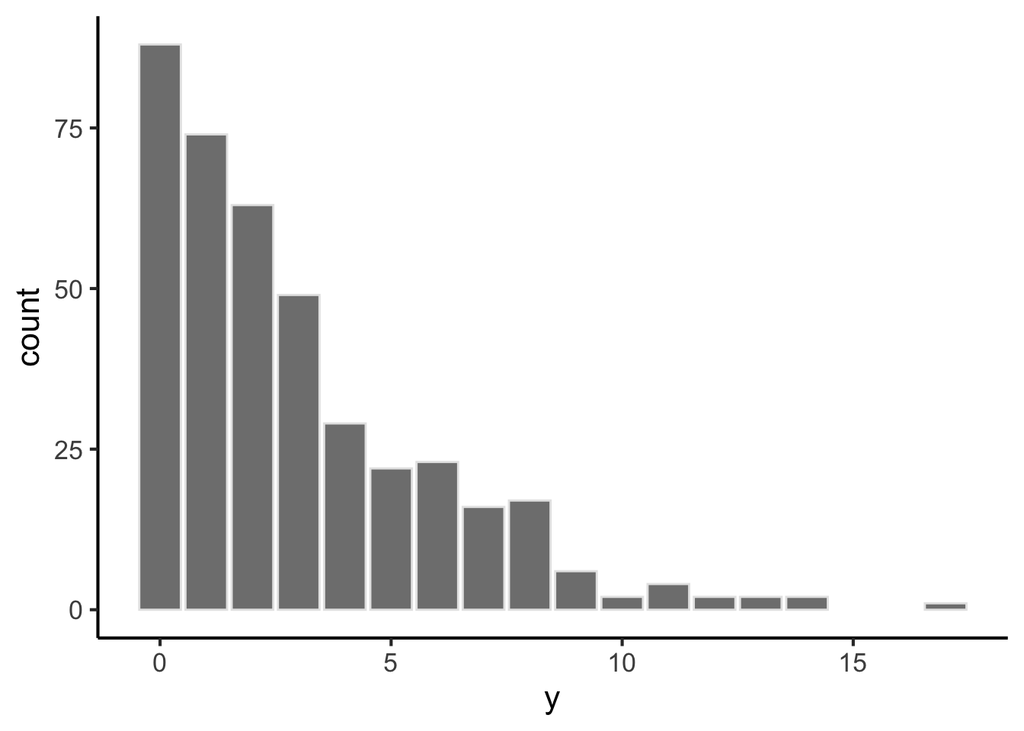

```r
ggplot(data = jpa, aes(x = y)) +
    geom_bar(fill = "grey50", color = "grey90")
```

- The mean is 2.93
- The variance is 8.832
- Overdispersion is about the **conditional** mean and variance but…
  - Does it seem like there might be overdispersion?
- What about zeroes?
  - Are there more or fewer zeroes than a Poisson distribution with this mean should have?

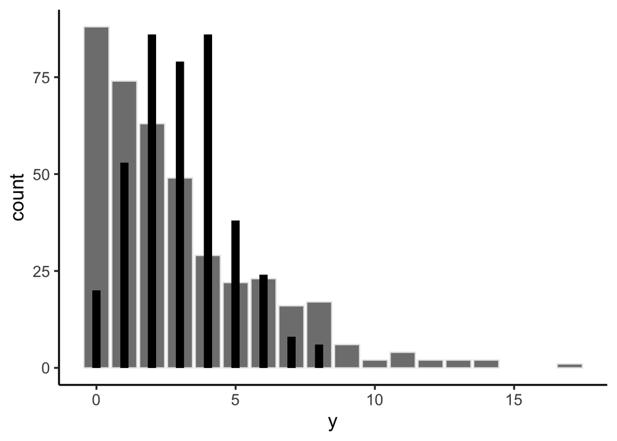

```r
# Simulate Poisson distributed data with same n and mean as data
pois_mean <- rpois(nrow(jpa), mean(jpa$y, na.rm = TRUE))
pois_mean_data <- data.frame(pois_mean)
ggplot(data = jpa, aes(x = y)) +
    geom_bar(fill = "grey50", color = "grey90") +
    geom_bar(data = pois_mean_data,
             aes(x = pois_mean),
             width = 0.3,
             fill = "black")
```

- Grey bars are the observed data
  - Narrower black bars are a Poisson distribution with the same mean (2.93)
- There are more zeroes in the data than in the Poisson distribution…
  - But the mis-match is not *just* the zeroes, so maybe just overdispersion

# `sensation` predicts `y`

## Scatterplot of `y` vs `sensation`

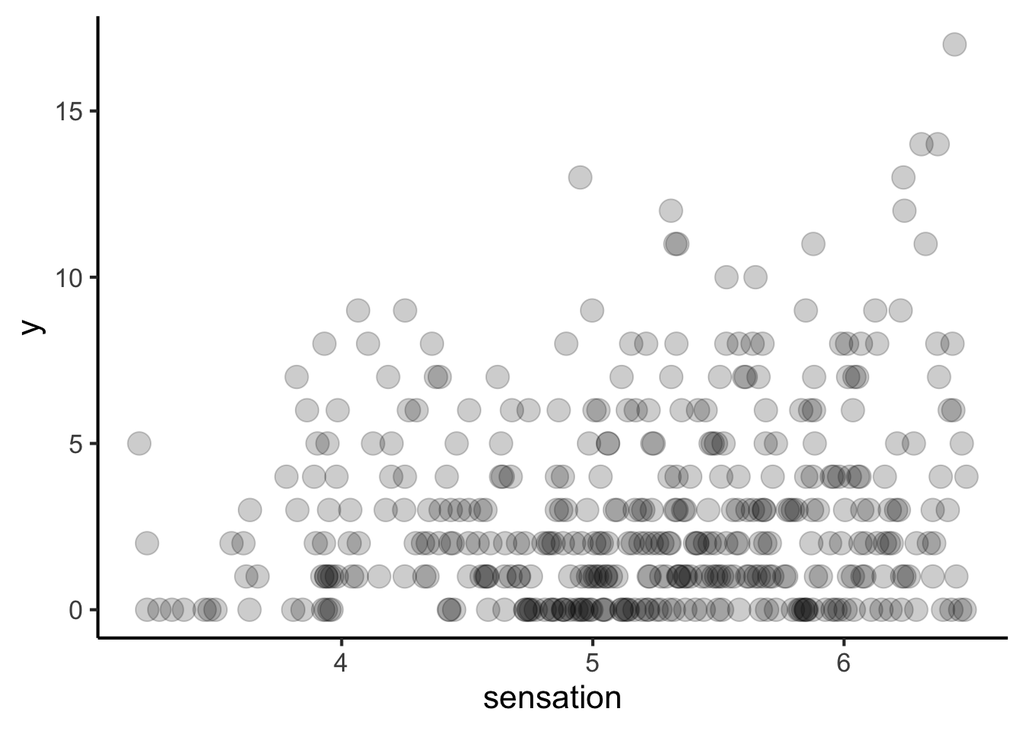

```r
ggplot(data = jpa, aes(x = sensation, y = y)) +
    geom_point(alpha = 0.2, size = 5)
```

## Poisson regression

- `sensation4` is centered at 4 (the midpoint of the 1 to 7 scale)
- `glm()` works very much like `lm()`
  - Additional options specify the type of GLiM
    - Here, Poisson regression (with **Poisson outcome distribution** and **log link function**) is specified by `family = poisson(link = "log")`

```r
jpa <- jpa %>% mutate(sensation4 = sensation - 4)
poi <- glm(y ~ sensation4,
           data = jpa,
           family = poisson(link = "log"))
summary(poi)
```

```
Call:
glm(formula = y ~ sensation4, family = poisson(link = "log"),
    data = jpa)

Deviance Residuals:
    Min       1Q   Median       3Q      Max
-2.7912  -1.5001  -0.4624   0.8418   4.9122

Coefficients:
            Estimate Std. Error z value Pr(>|z|)
(Intercept)  0.78560    0.05977  13.144  < 2e-16 ***
sensation4   0.23148    0.03966   5.837 5.33e-09 ***
---
Signif. codes:  0 '***' 0.001 '**' 0.01 '*' 0.05 '.' 0.1 ' ' 1

(Dispersion parameter for poisson family taken to be 1)

    Null deviance: 1186.8  on 399  degrees of freedom
Residual deviance: 1151.7  on 398  degrees of freedom
AIC: 2079

Number of Fisher Scoring iterations: 5
```

## Negative binomial regression

- `sensation4` is centered at 4 (the midpoint of the 1 to 7 scale)
- Negative binomial regression uses the `glm.nb()` function from the **MASS** package
  - It also works similarly to `lm()`
  - Specify data
  - Specify `outcome ~ predictor` relationship

```r
negbin <- glm.nb(data = jpa,
                 y ~ sensation4)
```

## Zero-inflated Poisson

- `sensation4` is centered at 4 (the midpoint of the 1 to 7 scale)
- ZIP model uses the `zeroinlf()` function from **pscl**
  - Specify `outcome ~ predictor` relationship *for counts*
  - Vertical bar (`|`) then predictors *for logistic portion*
  - `dist = "poisson"` for Poisson

```r
zip <- zeroinfl(y ~ sensation4 | sensation4,
               data = jpa,
               dist = "poisson")
summary(zip)
```

```
Call:
zeroinfl(formula = y ~ sensation4 | sensation4, data = jpa, dist = "poisson")

Pearson residuals:
    Min      1Q  Median      3Q     Max
-1.4675 -0.9658 -0.3395  0.7122  4.9638

Count model coefficients (poisson with log link):
            Estimate Std. Error z value Pr(>|z|)
(Intercept)  1.02579    0.06577  15.597  < 2e-16 ***
sensation4   0.21183    0.04304   4.922 8.57e-07 ***

Zero-inflation model coefficients (binomial with logit link):
            Estimate Std. Error z value Pr(>|z|)
(Intercept)  -1.2836     0.2633  -4.874 1.09e-06 ***
sensation4   -0.1152     0.1850  -0.622    0.534
---
Signif. codes:  0 '***' 0.001 '**' 0.01 '*' 0.05 '.' 0.1 ' ' 1

Number of iterations in BFGS optimization: 8
Log-likelihood: -953.4 on 4 Df
```

## Zero-inflated negative binomial

- `sensation4` is centered at 4 (the midpoint of the 1 to 7 scale)
- ZINB model uses the `zeroinlf()` function from **pscl**
  - Specify `outcome ~ predictor` relationship *for counts*
  - Vertical bar (`|`) then predictors *for logistic portion*
  - `dist = "negbin"` for negative binomial

```r
zinb <- zeroinfl(y ~ sensation4 | sensation4,
               data = jpa,
               dist = "negbin")
summary(zinb)
```

```
Call:
zeroinfl(formula = y ~ sensation4 | sensation4, data = jpa, dist = "negbin")

Pearson residuals:
    Min      1Q  Median      3Q     Max
-1.0135 -0.7001 -0.2655  0.5386  3.6749

Count model coefficients (negbin with log link):
            Estimate Std. Error z value Pr(>|z|)
(Intercept)  0.83395    0.11916   6.999 2.58e-12 ***
sensation4   0.23459    0.07372   3.182  0.00146 **
Log(theta)   0.52353    0.21971   2.383  0.01718 *

Zero-inflation model coefficients (binomial with logit link):
            Estimate Std. Error z value Pr(>|z|)
(Intercept)  -3.3179     2.1137  -1.570    0.116
sensation4    0.2957     1.0416   0.284    0.777
---
Signif. codes:  0 '***' 0.001 '**' 0.01 '*' 0.05 '.' 0.1 ' ' 1

Theta = 1.688
Number of iterations in BFGS optimization: 21
Log-likelihood: -882.4 on 5 Df
```

## Hurdle Poisson regression

- `sensation4` is centered at 4 (the midpoint of the 1 to 7 scale)
- Hurdle Poisson model uses the `hurdle()` function from **pscl**
  - Specify `outcome ~ predictor` relationship *for counts*
  - Vertical bar (`|`) then predictors *for logistic portion*
  - `dist = "poisson"` for Poisson

```r
hurdle_poi <- hurdle(y ~ sensation4 | sensation4,
                     data = jpa,
                     dist = "poisson")
summary(hurdle_poi)
```

```
Call:
hurdle(formula = y ~ sensation4 | sensation4, data = jpa, dist = "poisson")

Pearson residuals:
    Min      1Q  Median      3Q     Max
-1.4825 -0.9675 -0.3363  0.7135  4.9816

Count model coefficients (truncated poisson with log link):
            Estimate Std. Error z value Pr(>|z|)
(Intercept)  1.02798    0.06547  15.701  < 2e-16 ***
sensation4   0.21022    0.04283   4.908 9.22e-07 ***
Zero hurdle model coefficients (binomial with logit link):
            Estimate Std. Error z value Pr(>|z|)
(Intercept)   1.0158     0.2112   4.810 1.51e-06 ***
sensation4    0.2177     0.1556   1.399    0.162
---
Signif. codes:  0 '***' 0.001 '**' 0.01 '*' 0.05 '.' 0.1 ' ' 1

Number of iterations in BFGS optimization: 7
Log-likelihood: -953.5 on 4 Df
```

## Hurdle negative binomial regression

- `sensation4` is centered at 4 (the midpoint of the 1 to 7 scale)
- Hurdle negative binomial model uses the `hurdle()` function from **pscl**
  - Specify `outcome ~ predictor` relationship *for counts*
  - Vertical bar (`|`) then predictors *for logistic portion*
  - `dist = "negbin"` for negative binomial

```r
hurdle_nb <- hurdle(y ~ sensation4 | sensation4,
                     data = jpa,
                     dist = "negbin")
summary(hurdle_nb)
```

```
Call:
hurdle(formula = y ~ sensation4 | sensation4, data = jpa, dist = "negbin")

Pearson residuals:
    Min      1Q  Median      3Q     Max
-1.0293 -0.7031 -0.2626  0.5400  3.6705

Count model coefficients (truncated negbin with log link):
            Estimate Std. Error z value Pr(>|z|)
(Intercept)  0.84567    0.11672   7.245 4.32e-13 ***
sensation4   0.22666    0.07336   3.090   0.0020 **
Log(theta)   0.52851    0.21611   2.446   0.0145 *
Zero hurdle model coefficients (binomial with logit link):
            Estimate Std. Error z value Pr(>|z|)
(Intercept)   1.0158     0.2112   4.810 1.51e-06 ***
sensation4    0.2177     0.1556   1.399    0.162
---
Signif. codes:  0 '***' 0.001 '**' 0.01 '*' 0.05 '.' 0.1 ' ' 1

Theta: count = 1.6964
Number of iterations in BFGS optimization: 9
Log-likelihood: -882.5 on 5 Df
```

## Interpretation

### Base models: Poisson and negative binomial

- Poisson
  - RR = $e^{b_1}$ = $e^{0.231}$ = 1.26
    - For a 1 unit increase in `sensation4`, the predicted count is multiplied by 1.26
    - For a 1 unit increase in `sensation4`, the predicted count increases by 26 percent
- Negative binomial
  - RR = $e^{b_1}$ = $e^{0.22}$ = 1.247
    - For a 1 unit increase in `sensation4`, the predicted count is multiplied by 1.247
    - For a 1 unit increase in `sensation4`, the predicted count increases by 24.7 percent

### Zero-inflated models

- `sensation4` predicts which “0 drinks” responses are
  - Always 0: Never drinkers
  - Could be a positive count: Drinkers who didn’t drink this time
- If they *were* or *could be* a positive count, `sensation4` predicts
  - How many drinks (*0 or more*) they have
- Zero-inflated Poisson
  - RR = $e^{b_1}$ = $e^{0.212}$ = 1.236
    - For a 1 unit increase in `sensation4`, the predicted count is multiplied by 1.236
    - For a 1 unit increase in `sensation4`, the predicted count increases by 23.6 percent
  - OR = $e^{b_1}$ = $e^{-0.115}$ = 0.891
    - *Predicting excess zeroes*
    - For a 1 unit increase in `sensation4`, the predicted odds of excess zero is multiplied by 0.891
- Zero-inflated negative binomial
  - RR = $e^{b_1}$ = $e^{0.235}$ = 1.264
    - For a 1 unit increase in `sensation4`, the predicted count is multiplied by 1.264
    - For a 1 unit increase in `sensation4`, the predicted count increases by 26.4 percent
  - OR = $e^{b_1}$ = $e^{0.296}$ = 1.344
    - *Predicting excess zeroes*
    - For a 1 unit increase in `sensation4`, the predicted odds of excess zero is multiplied by 1.344

### Hurdle models

- `sensation4` predicts which “0 drinks” responses are
  - 0: Non-drinkers
  - Positive count: Drinkers
- If they have a positive count, `sensation4` predicts
  - How many drinks (*1 or more*) they have
- Hurdle Poisson
  - RR = $e^{b_1}$ = $e^{0.21}$ = 1.234
    - *Truncated Poisson model*
    - For a 1 unit increase in `sensation4`, the predicted count is multiplied by 1.234
    - For a 1 unit increase in `sensation4`, the predicted count increases by 23.4 percent
  - OR = $e^{b_1}$ = $e^{0.218}$ = 1.243
    - *Predicting positive (non-zero) counts*
    - For a 1 unit increase in `sensation4`, the predicted odds of positive count is multiplied by 1.243
- Hurdle NB
  - RR = $e^{b_1}$ = $e^{0.227}$ = 1.254
    - *Truncated negative binomial model*
    - For a 1 unit increase in `sensation4`, the predicted count is multiplied by 1.254
    - For a 1 unit increase in `sensation4`, the predicted count increases by 25.4 percent
  - OR = $e^{b_1}$ = $e^{0.218}$ = 1.243
    - *Predicting positive (non-zero) counts*
    - For a 1 unit increase in `sensation4`, the predicted odds of positive count is multiplied by 1.243

# Model comparisons

## Nested models

- Compare nested models with a likelihood ratio (LR) test
  - `lrtest()` function in **lmtest** package

### Poisson vs negative binomial

```r
lrtest(poi, negbin)
```

```
Likelihood ratio test

Model 1: y ~ sensation4
Model 2: y ~ sensation4
  #Df   LogLik Df  Chisq Pr(>Chisq)
1   2 -1037.51
2   3  -883.05  1 308.93  < 2.2e-16 ***
---
Signif. codes:  0 '***' 0.001 '**' 0.01 '*' 0.05 '.' 0.1 ' ' 1
```

### ZIP vs ZINB

```r
lrtest(zip, zinb)
```

```
Likelihood ratio test

Model 1: y ~ sensation4 | sensation4
Model 2: y ~ sensation4 | sensation4
  #Df  LogLik Df  Chisq Pr(>Chisq)
1   4 -953.39
2   5 -882.41  1 141.97  < 2.2e-16 ***
---
Signif. codes:  0 '***' 0.001 '**' 0.01 '*' 0.05 '.' 0.1 ' ' 1
```

### Hurdle Poisson vs hurdle negative binomial

```r
lrtest(hurdle_poi, hurdle_nb)
```

```
Likelihood ratio test

Model 1: y ~ sensation4 | sensation4
Model 2: y ~ sensation4 | sensation4
  #Df  LogLik Df Chisq Pr(>Chisq)
1   4 -953.46
2   5 -882.46  1   142  < 2.2e-16 ***
---
Signif. codes:  0 '***' 0.001 '**' 0.01 '*' 0.05 '.' 0.1 ' ' 1
```

## Nested and non-nested models

### Vuong test

- Compare non-nested models with the Vuong test
  - `vuong()` function in **pscl** package
- Overdispersion: Acceptable use of the Vuong test

```r
vuong(poi, negbin)
```

```
Vuong Non-Nested Hypothesis Test-Statistic:
(test-statistic is asymptotically distributed N(0,1) under the
 null that the models are indistinguishible)
-------------------------------------------------------------
              Vuong z-statistic             H_A    p-value
Raw                   -6.911618 model2 > model1 2.3958e-12
AIC-corrected         -6.911618 model2 > model1 2.3958e-12
BIC-corrected         -6.911618 model2 > model1 2.3958e-12
```

```r
vuong(zip, zinb)
```

```
Vuong Non-Nested Hypothesis Test-Statistic:
(test-statistic is asymptotically distributed N(0,1) under the
 null that the models are indistinguishible)
-------------------------------------------------------------
              Vuong z-statistic             H_A    p-value
Raw                   -4.990876 model2 > model1 3.0053e-07
AIC-corrected         -4.990876 model2 > model1 3.0053e-07
BIC-corrected         -4.990876 model2 > model1 3.0053e-07
```

```r
vuong(hurdle_poi, hurdle_nb)
```

```
Vuong Non-Nested Hypothesis Test-Statistic:
(test-statistic is asymptotically distributed N(0,1) under the
 null that the models are indistinguishible)
-------------------------------------------------------------
              Vuong z-statistic             H_A    p-value
Raw                   -4.997458 model2 > model1 2.9045e-07
AIC-corrected         -4.997458 model2 > model1 2.9045e-07
BIC-corrected         -4.997458 model2 > model1 2.9045e-07
```

- Zero-inflated vs not: Not recommended, but…

```r
vuong(poi, zip)
```

```
Vuong Non-Nested Hypothesis Test-Statistic:
(test-statistic is asymptotically distributed N(0,1) under the
 null that the models are indistinguishible)
-------------------------------------------------------------
              Vuong z-statistic             H_A    p-value
Raw                   -5.081704 model2 > model1 1.8703e-07
AIC-corrected         -4.960883 model2 > model1 3.5087e-07
BIC-corrected         -4.719756 model2 > model1 1.1806e-06
```

```r
vuong(negbin, zinb)
```

```
Vuong Non-Nested Hypothesis Test-Statistic:
(test-statistic is asymptotically distributed N(0,1) under the
 null that the models are indistinguishible)
-------------------------------------------------------------
              Vuong z-statistic             H_A    p-value
Raw                  -0.5890815 model2 > model1    0.27790
AIC-corrected         1.2529411 model1 > model2    0.10511
BIC-corrected         4.9291249 model1 > model2 4.1299e-07
```

```r
vuong(poi, hurdle_poi)
```

```
Vuong Non-Nested Hypothesis Test-Statistic:
(test-statistic is asymptotically distributed N(0,1) under the
 null that the models are indistinguishible)
-------------------------------------------------------------
              Vuong z-statistic             H_A    p-value
Raw                   -5.081285 model2 > model1 1.8745e-07
AIC-corrected         -4.960379 model2 > model1 3.5178e-07
BIC-corrected         -4.719083 model2 > model1 1.1846e-06
```

```r
vuong(negbin, hurdle_nb)
```

```
Vuong Non-Nested Hypothesis Test-Statistic:
(test-statistic is asymptotically distributed N(0,1) under the
 null that the models are indistinguishible)
-------------------------------------------------------------
              Vuong z-statistic             H_A    p-value
Raw                   -0.570066 model2 > model1   0.284316
AIC-corrected          1.368579 model1 > model2   0.085565
BIC-corrected          5.237595 model1 > model2 8.1341e-08
```

### AIC

- Can be used to compare anything, nested or not
  - But no actual test
  - Just lower is better

```r
Model <- c("Poisson", "Negative binomial",
           "ZIP", "ZINB",
           "Hurdle Poisson", "Hurdle NB")
AIC <- c(AIC(poi),
         AIC(negbin),
         AIC(zip),
         AIC(zinb),
         AIC(hurdle_poi),
         AIC(hurdle_nb))
aic_dat <- data.frame(Model, AIC)
aic_dat
```

```
              Model      AIC
1           Poisson 2079.025
2 Negative binomial 1772.091
3               ZIP 1914.786
4              ZINB 1774.812
5    Hurdle Poisson 1914.918
6         Hurdle NB 1774.915
```

```r
kable(aic_dat, digits = 3, row.names = F)
```

| Model | AIC |
| --- | --- |
| Poisson | 2079.025 |
| Negative binomial | 1772.091 |
| ZIP | 1914.786 |
| ZINB | 1774.812 |
| Hurdle Poisson | 1914.918 |
| Hurdle NB | 1774.915 |

# $R^2$ values

- All the $R^2$ functions we talked about only work for Poisson, overdispersed Poisson, and negative binomial
  - They don’t work for zero-inflated or hurdle models
  - Error or `NA`

```r
r2_mcfadden(poi)
```

```
# R2 for Generalized Linear Regression
       R2: 0.017
  adj. R2: 0.016
```

```r
r2_mcfadden(negbin)
```

```
# R2 for Generalized Linear Regression
       R2: 0.006
  adj. R2: 0.005
```

# Predicted counts

- Code adapted from the Atkins & Gallop (2007) article (Figure 1)
  - `predprob()` function from **pscl** package calculates predicted probabilities of count values based on the model
    - Predicted probability of *each outcome value* for each person
      - Not just the person’s predicted value
    - Then take the mean for each outcome value (column) using `apply()`
      - The `2` tells it to get the mean for each *column*
      - One predicted probability for each value of the outcome
    - Put those in a dataset with the possible outcome values (0 to 17)

```r
phat.poi <- predprob(poi)
phat.poi.mn <- apply(phat.poi, 2, mean)
phat.poi.mn
```

```
           0            1            2            3            4            5
6.056008e-02 1.623542e-01 2.248151e-01 2.141266e-01 1.575259e-01 9.526311e-02
           6            7            8            9           10           11
4.921052e-02 2.227976e-02 9.003242e-03 3.291494e-03 1.100031e-03 3.388502e-04
          12           13           14           15           16           17
9.685088e-05 2.582863e-05 6.457106e-06 1.519367e-06 3.376747e-07 7.110293e-08
```

```r
phat.nb <- predprob(negbin)
phat.nb.mn <- apply(phat.nb, 2, mean)
phat.nb.mn
```

```
          0           1           2           3           4           5
0.211057742 0.196228947 0.157236212 0.119481715 0.088439808 0.064485584
          6           7           8           9          10          11
0.046583338 0.033448680 0.023921853 0.017063203 0.012149942 0.008642031
         12          13          14          15          16          17
0.006143087 0.004365497 0.003102169 0.002204766 0.001567418 0.001114748
```

```r
phat.zinb <- predprob(zinb)
phat.zinb.mn <- apply(phat.zinb, 2, mean)
phat.zinb.mn
```

```
           0            1            2            3            4            5
0.2194524247 0.1811723969 0.1548981572 0.1216739760 0.0915082025 0.0670751649
           6            7            8            9           10           11
0.0483637690 0.0344884766 0.0244057592 0.0171770515 0.0120424296 0.0084190987
          12           13           14           15           16           17
0.0058742109 0.0040928156 0.0028488899 0.0019817805 0.0013780752 0.0009581048
```

```r
x <- seq(0, 17, 1)
probs <- data.frame(x, phat.poi.mn, phat.nb.mn, phat.zinb.mn)
probs
```

```
    x  phat.poi.mn  phat.nb.mn phat.zinb.mn
0   0 6.056008e-02 0.211057742 0.2194524247
1   1 1.623542e-01 0.196228947 0.1811723969
2   2 2.248151e-01 0.157236212 0.1548981572
3   3 2.141266e-01 0.119481715 0.1216739760
4   4 1.575259e-01 0.088439808 0.0915082025
5   5 9.526311e-02 0.064485584 0.0670751649
6   6 4.921052e-02 0.046583338 0.0483637690
7   7 2.227976e-02 0.033448680 0.0344884766
8   8 9.003242e-03 0.023921853 0.0244057592
9   9 3.291494e-03 0.017063203 0.0171770515
10 10 1.100031e-03 0.012149942 0.0120424296
11 11 3.388502e-04 0.008642031 0.0084190987
12 12 9.685088e-05 0.006143087 0.0058742109
13 13 2.582863e-05 0.004365497 0.0040928156
14 14 6.457106e-06 0.003102169 0.0028488899
15 15 1.519367e-06 0.002204766 0.0019817805
16 16 3.376747e-07 0.001567418 0.0013780752
17 17 7.110293e-08 0.001114748 0.0009581048
```

- Plot of histogram of observed outcome values
  - Plus predicted values for Poisson regression model (solid black line)
  - Plus predicted values for negative binomial model (dashed blue line)
  - Plus predicted values for ZINB (dotted red line)

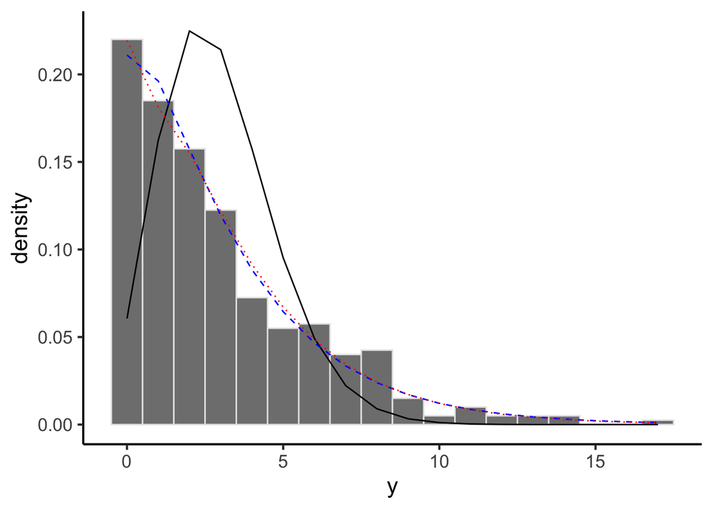

```r
ggplot(data = jpa, aes(x = y, y = after_stat(density))) +
    geom_histogram(binwidth = 1, fill = "grey50", color = "grey90") +
    geom_line(data = probs,
              aes(x = x, y = phat.poi.mn),
              linetype = "solid",
              color = "black") +
    geom_line(data = probs,
              aes(x = x, y = phat.nb.mn),
              linetype = "dashed",
              color = "blue") +
    geom_line(data = probs,
              aes(x = x, y = phat.zinb.mn),
              linetype = "dotted",
              color = "red")
```

# Class task

- Which model best represents the data?
  - Is there overdispersion?
  - Is there zero-inflation?
  - Is there both?
- Does the best model do a good job of reproducing the observed counts?
- How much variance in the outcome is predicted by the predictor?